# week2proj

Charley Ferrari

June 24, 2016

## Evaluating Recommendation Algorithms.

I’ll be looking at item based and user based collaborative filtering. Below are lists of the parameters I can tweak:

```r
recommenderRegistry$get_entries(dataType =  "realRatingMatrix")$IBCF_realRatingMatrix
```

```
## Recommender method: IBCF
## Description: Recommender based on item-based collaborative filtering (real data).
## Parameters:
##    k method normalize normalize_sim_matrix alpha na_as_zero
## 1 30 Cosine    center                FALSE   0.5      FALSE
```

```r
recommenderRegistry$get_entries(dataType =  "realRatingMatrix")$UBCF_realRatingMatrix
```

```
## Recommender method: UBCF
## Description: Recommender based on user-based collaborative filtering (real data).
## Parameters:
##   method nn sample normalize
## 1 cosine 25  FALSE    center
```

I’ll tweak different variables one at a time, to get a sense for how they will affect my models. For IBCF, I’ll tweak k, similarity method (either cosine or pearson), and the normalization method (center or z-score).

The ratings I’ll be using is the built in dataset: Jester5k. Jester5k is a collection of joke ratings for 100 jokes by 5000 users, with 362106 ratings. First, lets look at a Histogram of the ratings:

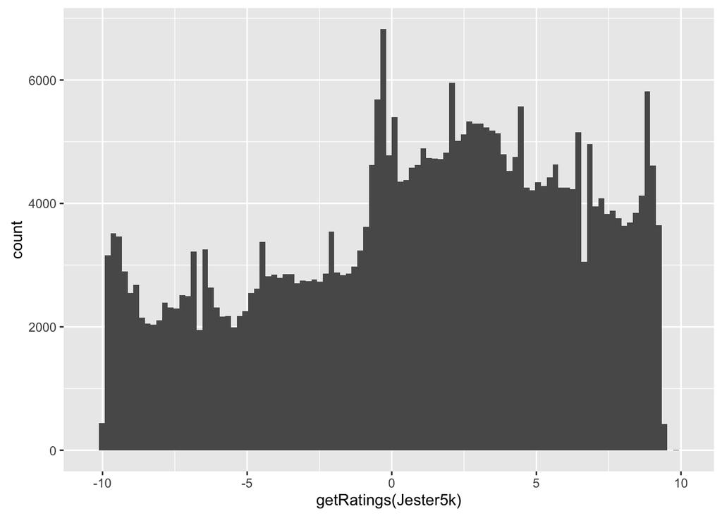

```r
qplot(getRatings(Jester5k), bins=100)
```

It looks like these ratings vary from -10 to 10. There is still an overall mean of 0.85, so centering the ratings will help normalize the ratings. Lets also look at the average ratings by user:

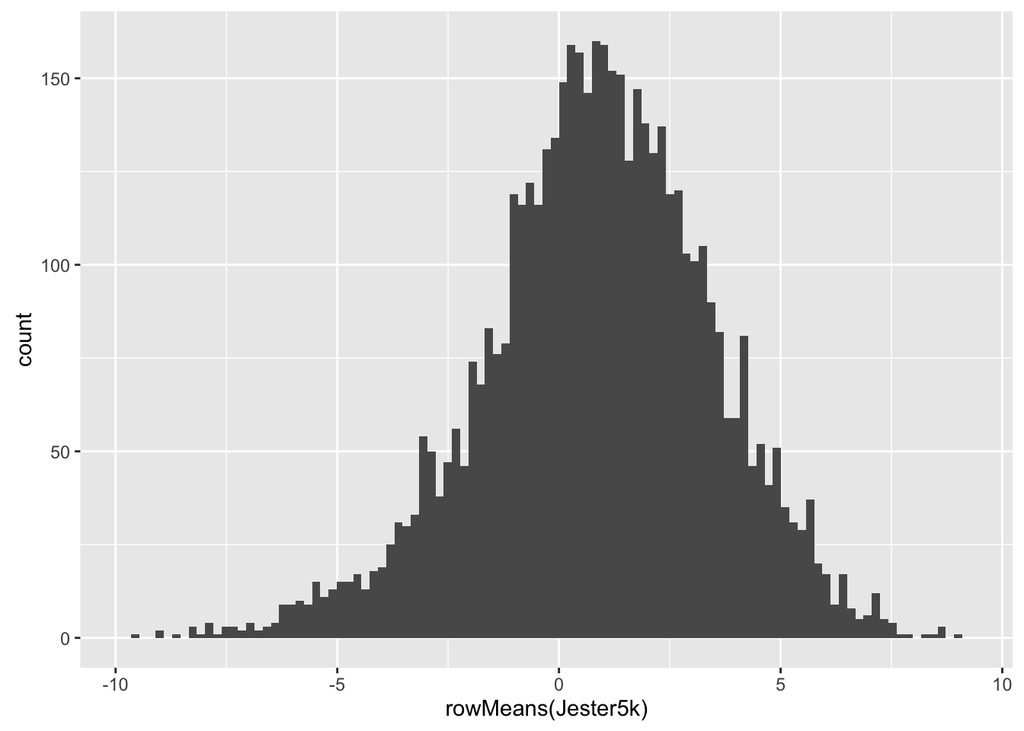

```r
qplot(rowMeans(Jester5k), bins=100)
```

and the average rating by joke:

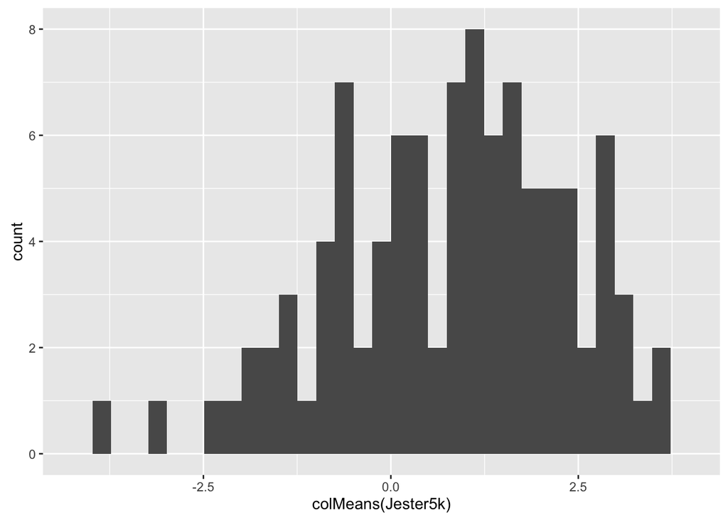

```r
qplot(colMeans(Jester5k))
```

These both appear to be roughly normally distributed. As our first evaluation technique, we’ll hold k constant at 30, and tweak our similarity methods and normalization techniques. Both of these have two choices we’ll be evaluating: z-score and centered for normalization and Pearson and Cosine for the similarity measure.)

```r
algorithms <- list(
  "z-score / cosine" = list(name="IBCF", param=list(normalize = "Z-score")),
  "z-score / pearson" = list(name="IBCF", param=list(normalize = "Z-score",
                                                     method = "Pearson")),
  "center / cosine" = list(name="IBCF", param=list()),
  "center / pearson" = list(name="IBCF", param=list(method = "Pearson"))

)

scheme <- evaluationScheme(Jester5k, method = "split", train = .9,
                           k = 1, given = 20, goodRating = 4)

scheme <- evaluationScheme(Jester5k, method="split", train=0.8, given=15, goodRating=5)

results <- evaluate(scheme, algorithms, n=c(1, 3, 5, 10, 15, 20))
```

```
## IBCF run fold/sample [model time/prediction time]
##   1  [1.313sec/1.053sec]
## IBCF run fold/sample [model time/prediction time]
##   1  [1.153sec/0.786sec]
## IBCF run fold/sample [model time/prediction time]
##   1  [0.922sec/0.633sec]
## IBCF run fold/sample [model time/prediction time]
##   1  [0.882sec/0.667sec]
```

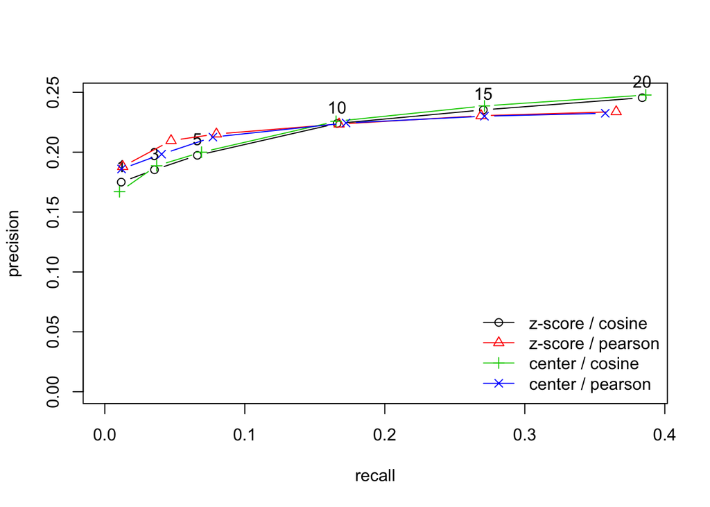

```r
plot(results, "prec/rec", annotate = TRUE, main = "Precision-recall")
```

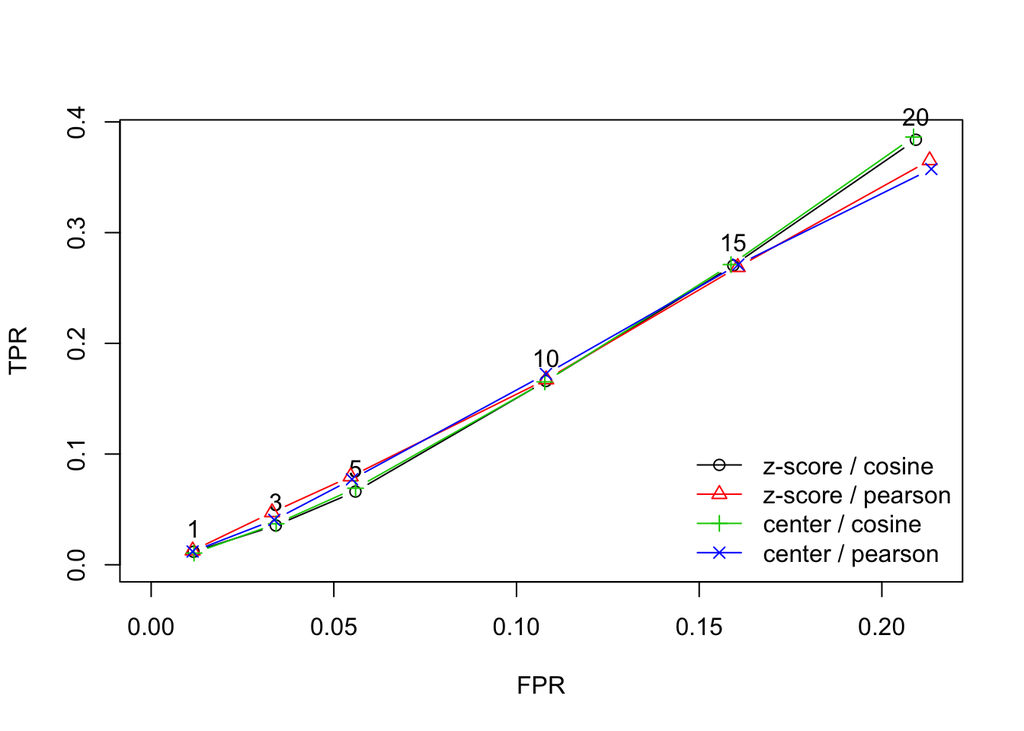

```r
plot(results, annotate = 1, main = 'ROC Curve')
```

Our results look very similar, with cosine distance performing slightly better than pearson (and there being little effect with z-score versus center.)

Next, we could look at different values of k and see how varying the number of nearest neighbors affects things.

```r
algorithms <- list(
  "k = 2" = list(name="IBCF", param=list(k = 1)),
  "k = 5" = list(name="IBCF", param=list(k = 5)),
  "k = 10" = list(name="IBCF", param=list(k = 10)),
  "k = 25" = list(name="IBCF", param=list(k = 25)),
  "k = 50" = list(name="IBCF", param=list(k = 50)),
  "k = 75" = list(name="IBCF", param=list(k=75))

)

scheme <- evaluationScheme(Jester5k, method = "split", train = .9,
                           k = 1, given = 20, goodRating = 4)

results <- evaluate(scheme, algorithms, n=c(1, 3, 5, 10, 15, 20))
```

```
## IBCF run fold/sample [model time/prediction time]
##   1  [1.041sec/0.223sec]
## IBCF run fold/sample [model time/prediction time]
##   1  [1.031sec/0.545sec]
## IBCF run fold/sample [model time/prediction time]
##   1  [0.998sec/0.293sec]
## IBCF run fold/sample [model time/prediction time]
##   1  [1.038sec/0.319sec]
## IBCF run fold/sample [model time/prediction time]
##   1  [1.27sec/0.295sec]
## IBCF run fold/sample [model time/prediction time]
##   1  [1.046sec/0.329sec]
```

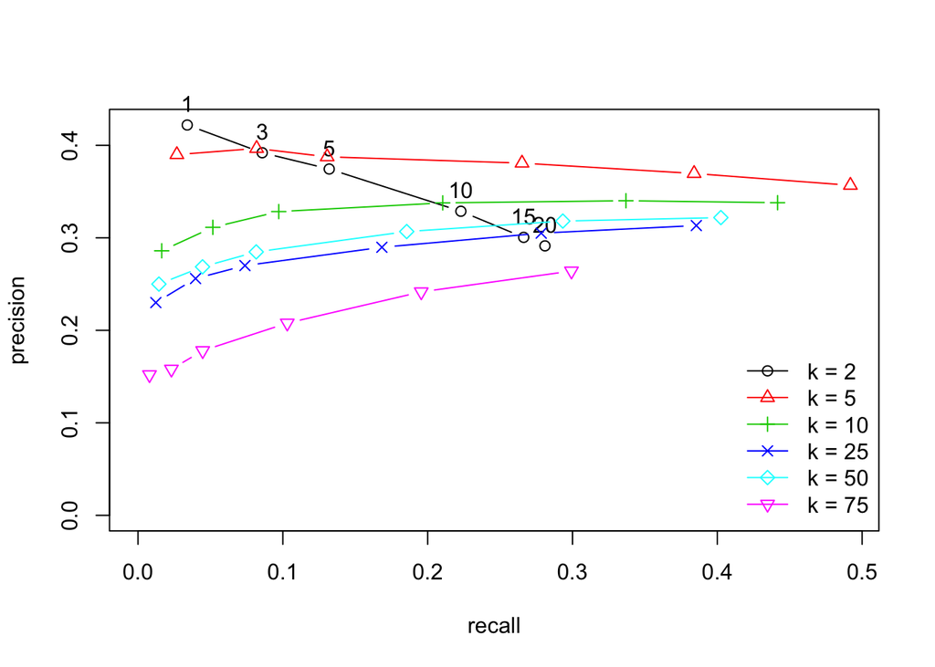

```r
plot(results, "prec/rec", annotate = TRUE, main = "Precision-recall")
```

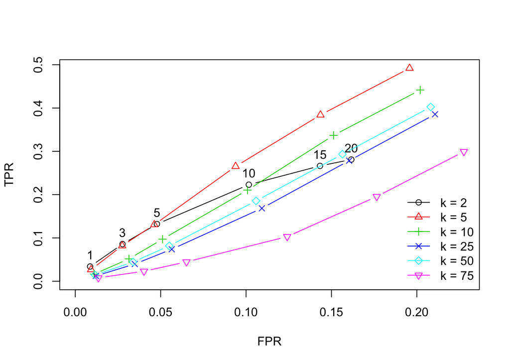

```r
plot(results, annotate = 1, main = 'ROC Curve')
```

Lastly, we could compare IBCF and UBCF.

```r
algorithms <- list(
  IBCF = list(name="IBCF", param=list()),
  UBCF = list(name="UBCF", param=list())

)

scheme <- evaluationScheme(Jester5k, method = "split", train = .9,
                           k = 1, given = 20, goodRating = 4)

results <- evaluate(scheme, algorithms, n=c(1, 3, 5, 10, 15, 20))
```

```
## IBCF run fold/sample [model time/prediction time]
##   1  [1.068sec/0.367sec]
## UBCF run fold/sample [model time/prediction time]
##   1  [0.136sec/9.935sec]
```

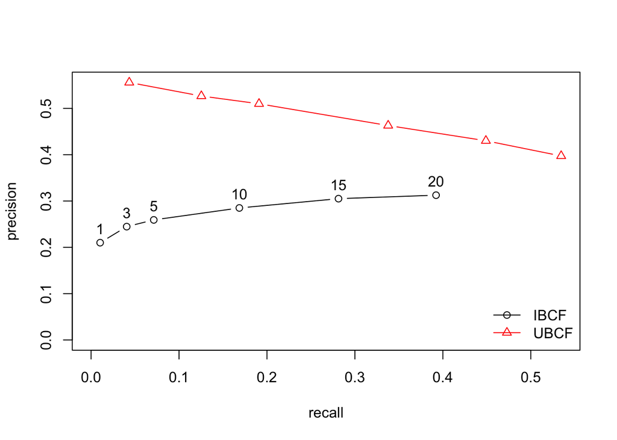

```r
plot(results, "prec/rec", annotate = TRUE, main = "Precision-recall")
```

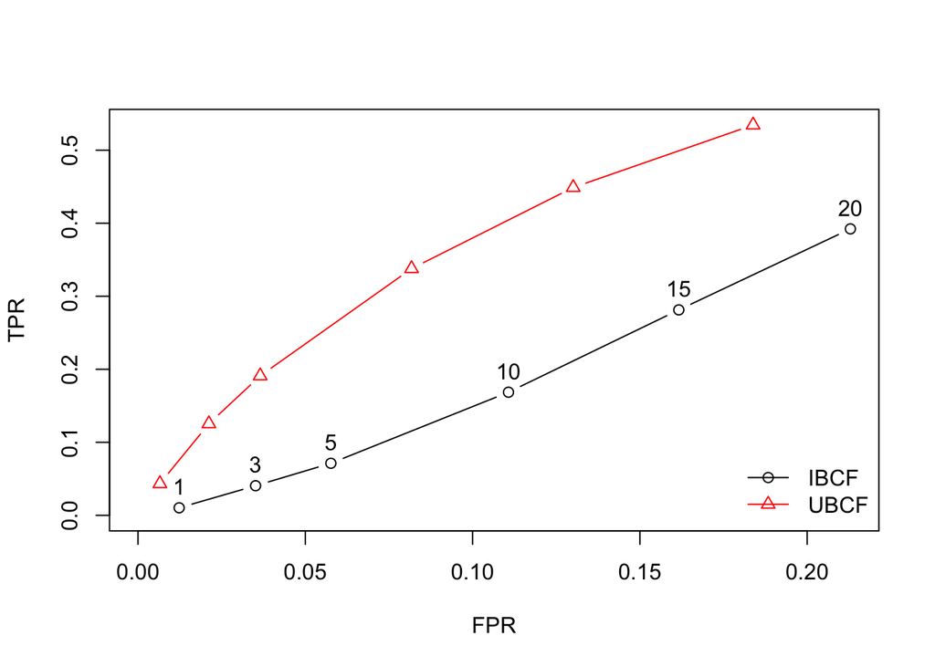

```r
plot(results, annotate = 1, main = 'ROC Curve')
```

The user based collaborative method seems to perform better than the item based method.

[This page](http://www.r-bloggers.com/testing-recommender-systems-in-r/) which gave me some of the inspiration for the code in this project, explains the trade off in using IBCF versus UBCF. Apparently UBCF is a more computationally intensive method, while IBCF only calculates based on the k closest individuals (and not across the entire matrix.)